# Лабораторная работа №8

Поиск файлов. Перенаправление ввода-вывода. Просмотр запущенных процессов

Горбачев Алексей.

Российский университет дружбы народов, Москва, Россия

# Информация

## Докладчик

- Горбачев Алексей
- студент НБИбд-01-23
- Российский университет дружбы народов

# Вводная часть

## Вводная часть

В операционной системе типа Linux взаимодействие пользователя с системой обычно осуществляется с помощью командной строки посредством построчного ввода ко- манд. При этом обычно используется командные интерпретаторы языка shell: /bin/sh; /bin/csh; /bin/ksh. Формат команды. Командой в операционной системе называется записанный по специальным правилам текст (возможно с аргументами), представляющий собой ука- зание на выполнение какой-либо функций (или действий) в операционной системе. Обычно первым словом идёт имя команды, остальной текст — аргументы или опции, конкретизирующие действие.

## Объект и предмет исследования

- Перенаправление ввода-вывода
- Конвейер
- Поиск файла
- Проверка использования диска
- Управление процессами
- Получение информации о процессах

# Цель работы

## Цель работы

Ознакомление с инструментами поиска файлов и фильтрации текстовых данных. Приобретение практических навыков: по управлению процессами (и заданиями), по проверке использования диска и обслуживанию файловых систем.

# Выполнение лабораторной работы

## 1

Осуществите вход в систему, используя соответствующее имя пользователя.

## 2

Запишем в файл file.txt названия файлов, содержащихся в каталоге /etc. Допи- шите в этот же файл названия файлов, содержащихся в вашем домашнем каталоге

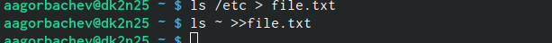

выполнение команды

## 3

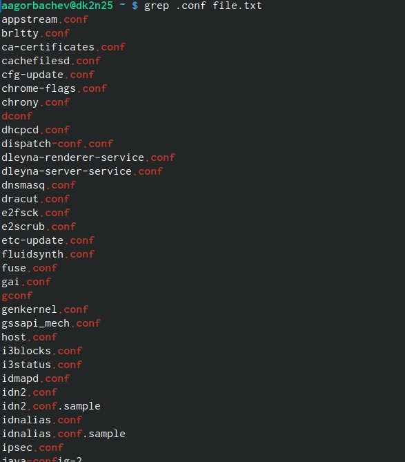

вывод файлов

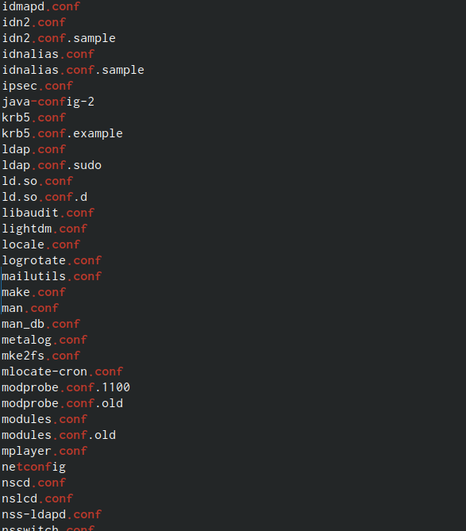

## 4

Определим какие файлы в домашнем каталоге начинаются с символа с.

[figure not shown]

два варианта

## 5

Выведем на экран имена файлов из каталога /etc, начинающиеся с символа h

[figure not shown]

##

[figure not shown]

выполнеине команды

## 6

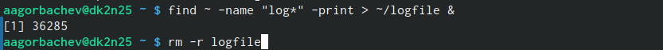

выполнение команды

## 7

Запустим из консоли в фоновом редиме gedit.

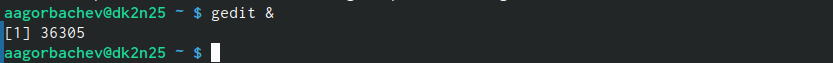

запуск gedit

## 8

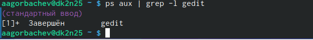

выполнение команды

## 9

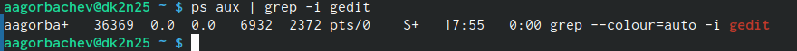

выполнение команды

## 10

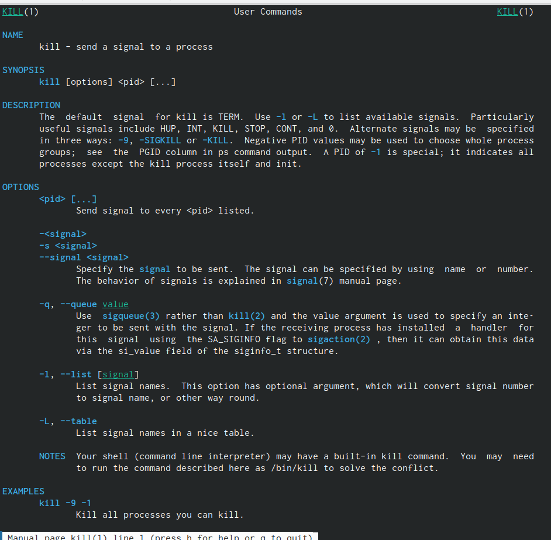

выполнение команды

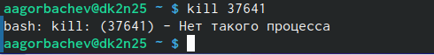

выполнение команды

## 11

Изучим и выполним команды df и du

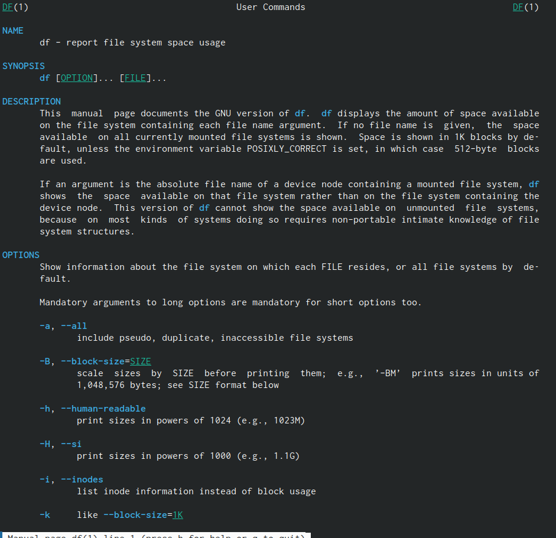

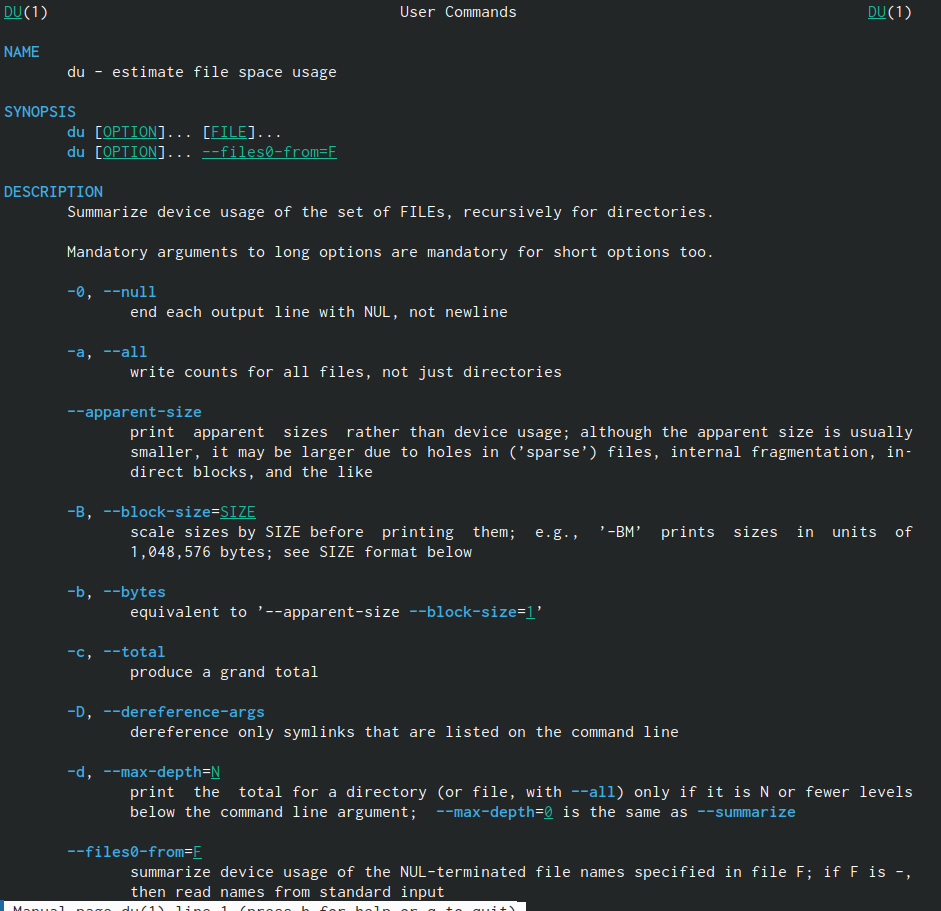

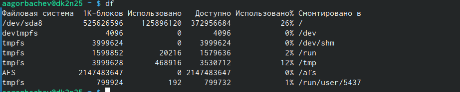

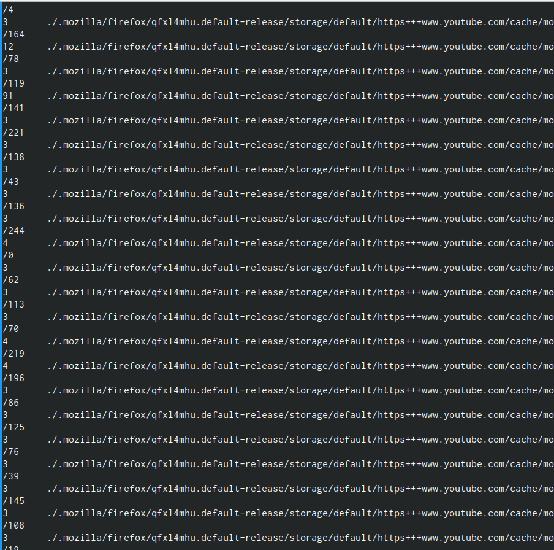

## 12

С помощью команды find выведем именя всех директорий

[figure not shown]

выполнение команды

[figure not shown]

выполнение команды

# Вывод

## Выводы

Мы ознакомились с инструментами поиска файлов и фильтрации текстовых данных. Приобрели практические навыки: по управлению процессами (и заданиями), по проверке использования диска и обслуживанию файловых систем.